# DeSimone_MS64060_Assignment 4

##Now I will examine 2 specific attributes - ROE & ROA - The higher the ROE & ROA are, the better the firm is performing and will probably continue to perform well.

```r
ROE.ROA.DF=read.csv("C:/Users/hdesi/Desktop/MBA/Machine Learning/Pharmaceuticals.csv")[,c(6,7)]
set.seed(123)
summary(ROE.ROA.DF)
```

```
##       ROE            ROA
##  Min.   : 3.9   Min.   : 1.40
##  1st Qu.:14.9   1st Qu.: 5.70
##  Median :22.6   Median :11.20
##  Mean   :25.8   Mean   :10.51
##  3rd Qu.:31.0   3rd Qu.:15.00
##  Max.   :62.9   Max.   :20.30
```

##Looking for the best k value

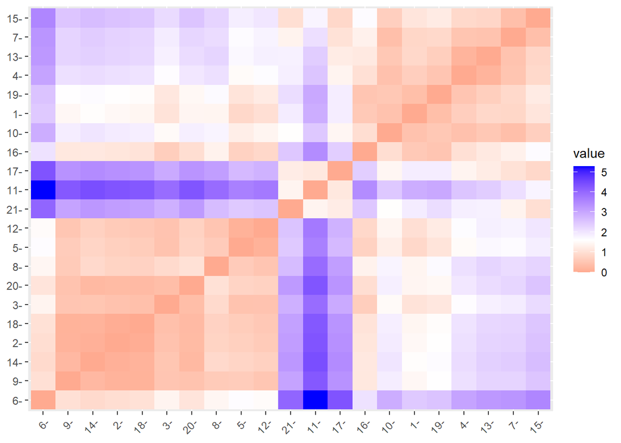

```r
ROE.ROA.DF <- scale(ROE.ROA.DF) #z-score
distance <- get_dist(ROE.ROA.DF)
fviz_dist(distance)
```

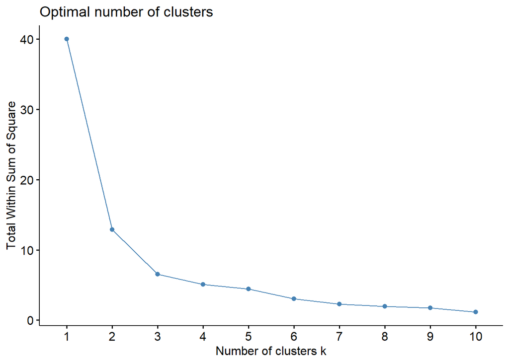

```r
fviz_nbclust(ROE.ROA.DF, kmeans, method = "wss")##elbow
```

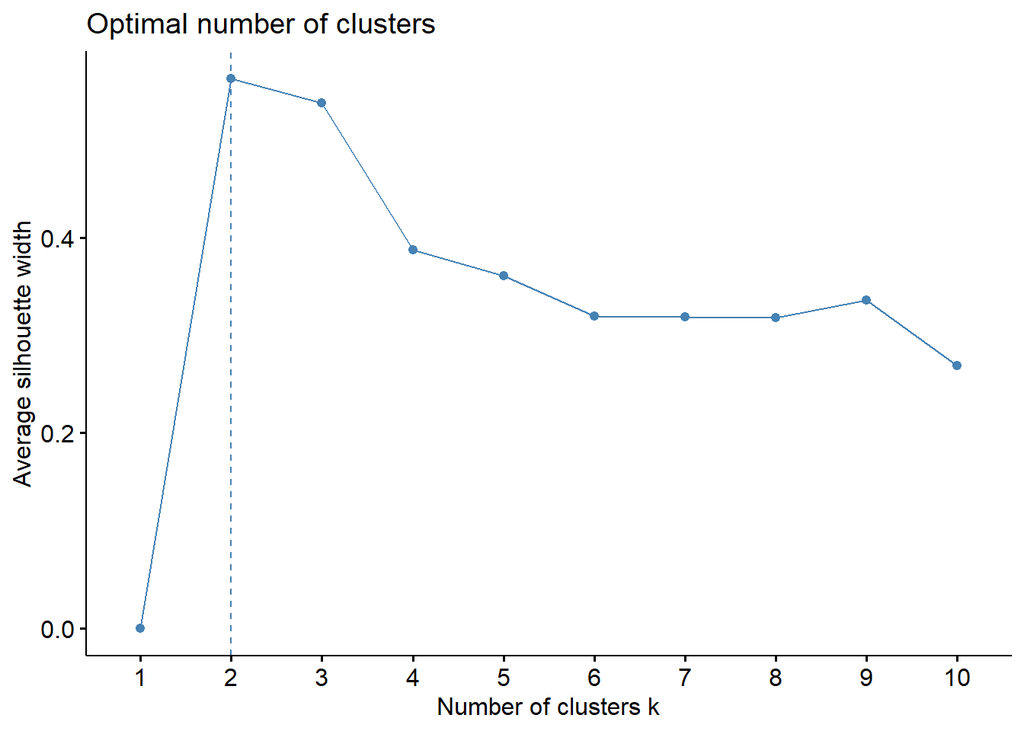

```r
fviz_nbclust(ROE.ROA.DF, kmeans, method = "silhouette")
```

##Based on both methods, k=2 or k=3 is optimal - we will use 3 as 2 is too insignificant

```r
ROA.ROE.PERFORMANCE <- kmeans(ROE.ROA.DF, centers = 3, nstart = 25)
ROA.ROE.PERFORMANCE$centers
```

```
##          ROE        ROA
## 1  1.9006613  1.3378151
## 2  0.1900740  0.6456412
## 3 -0.7222576 -0.9178575
```

```r
ROA.ROE.PERFORMANCE$size
```

```
## [1]  3  8 10
```

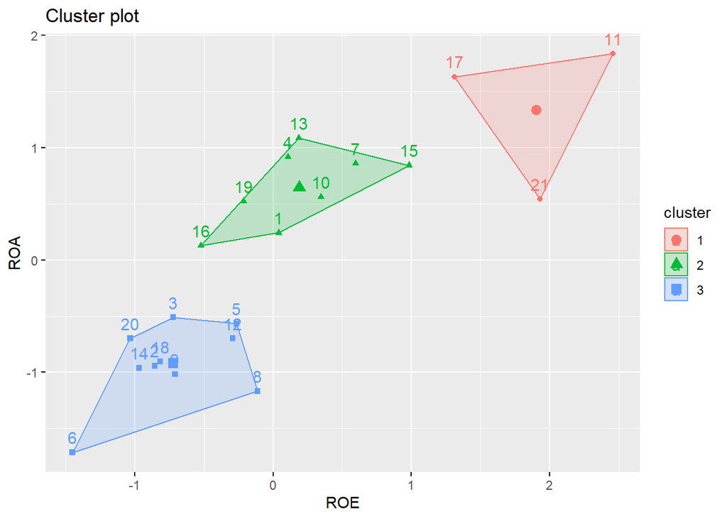

```r
## 3, 8, 10

fviz_cluster(ROA.ROE.PERFORMANCE, data = ROE.ROA.DF) ##Visual
```

##Firms in cluster 1 have the highest ROA and ROE - data points 11,17, & 21 ##Best: 11 - GlaxoSmithKline plc ##Also High Performers: 17 - Pfizer Inc 21 - Wyeth

##We will examine the market capitalization and the price to earnings ratio to determine the worth of a firm (in terms of investing).

```r
FIRM.WORTH.DF=read.csv("C:/Users/hdesi/Desktop/MBA/Machine Learning/Pharmaceuticals.csv")[,c(3,5)]
set.seed(123)
summary(FIRM.WORTH.DF)
```

```
##    Market_Cap        PE_Ratio
##  Min.   :  0.41   Min.   : 3.60
##  1st Qu.:  6.30   1st Qu.:18.90
##  Median : 48.19   Median :21.50
##  Mean   : 57.65   Mean   :25.46
##  3rd Qu.: 73.84   3rd Qu.:27.90
##  Max.   :199.47   Max.   :82.50
```

##Looking for the best k value

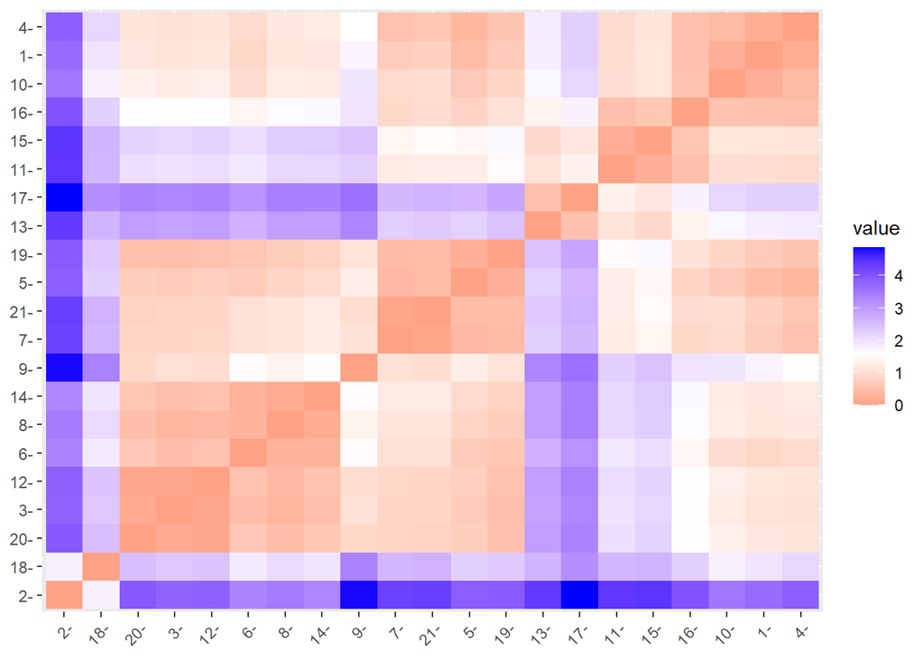

```r
FIRM.WORTH.DF <- scale(FIRM.WORTH.DF) #z-score
distance <- get_dist(FIRM.WORTH.DF)
fviz_dist(distance)
```

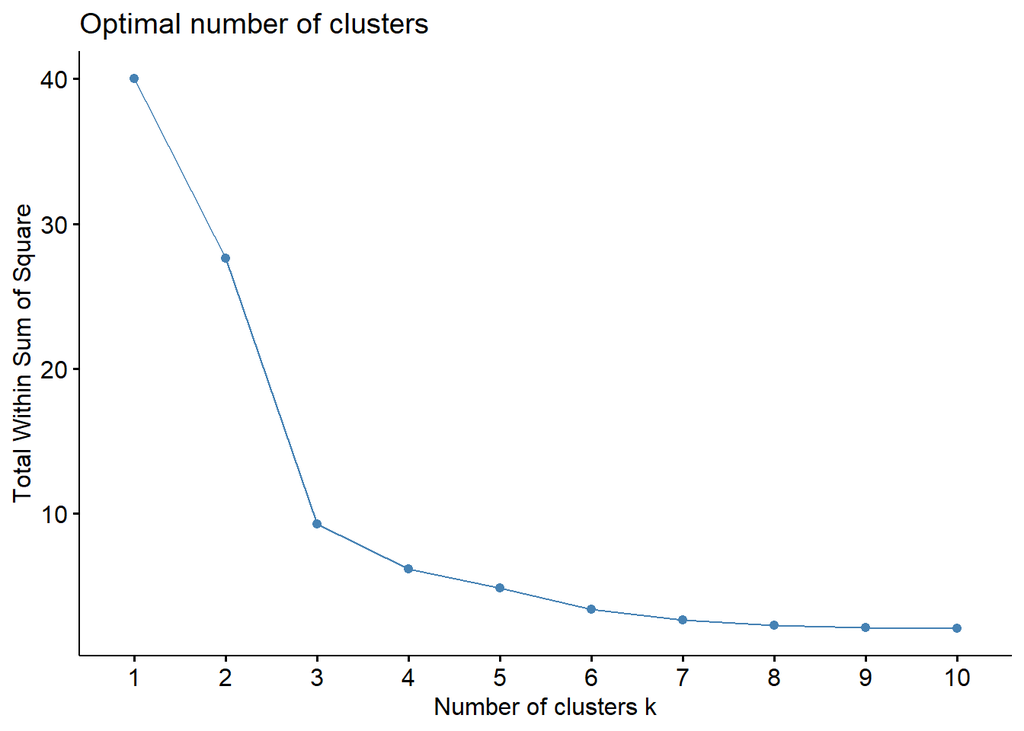

```r
fviz_nbclust(FIRM.WORTH.DF, kmeans, method = "wss")##elbow
```

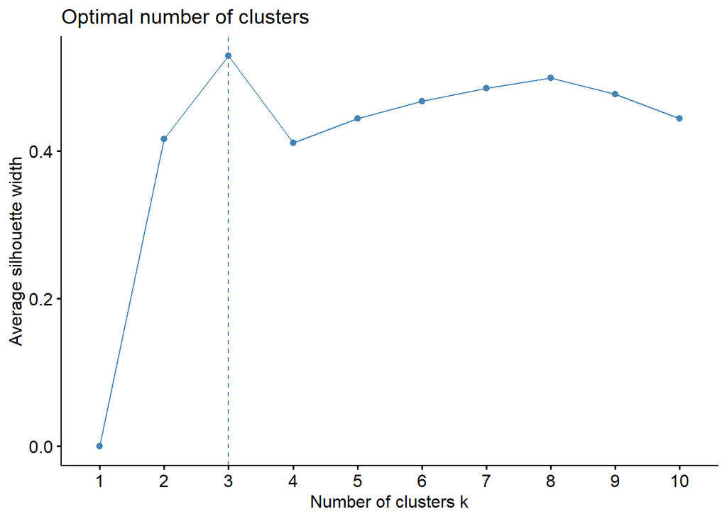

```r
fviz_nbclust(FIRM.WORTH.DF, kmeans, method = "silhouette")
```

##Based on both methods, k=3 is optimal

```r
FIRM.WORTH <- kmeans(FIRM.WORTH.DF, centers = 3, nstart = 25)
FIRM.WORTH$centers
```

```
##   Market_Cap   PE_Ratio
## 1  1.4895591 -0.2061221
## 2 -0.4692352 -0.3121028
## 3 -0.4392513  2.7000246
```

```r
FIRM.WORTH$size
```

```
## [1]  5 14  2
```

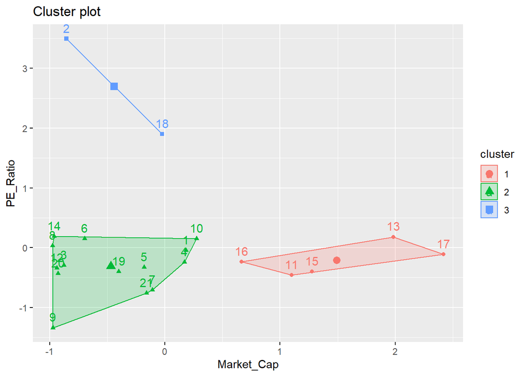

```r
## 5, 14, 2

fviz_cluster(FIRM.WORTH, data = FIRM.WORTH.DF) ##Visual
```

##Are other attributes are valuable to look at, but the 4 I have chosen to concentrate on will lead to the best odds of high performance if stock is purchased. Looking into the other attributes may cloud the waters.

##If only one stock can be purchased than the best option would be Pfizer Inc who is located in high performing ares in their clusters of both segmentations.